# Use Wearable Devices Data to Predict Activity Quality

Xing Liu

4/2/2017

## Background

Wearable devices are becoming integrated into modern life. Among their various features, most devices record the physcial activities of their owner and provide wellness diagnosis based on collected data. The data analyzed in this project comes from on-body movement measurements of people lifting weights (http://groupware.les.inf.puc-rio.br/har). Participants are asked to perform weight-lifting with the correct execution and four other ways that correspond to four different common mistakes. The goal is to predict which out of the five categories did one lift weight based on measurements from accelerometers attached to the belt, forearm, arm and dumbell.

## Import and Clean Data

```r
library(caret)
library(randomForest)
library(AppliedPredictiveModeling)
```

After loading necessary libraries to be used in training models, download the training and testing data from their URLs.

```r
trainingURL <- "https://d396qusza40orc.cloudfront.net/predmachlearn/pml-training.csv"
testingURL <- "https://d396qusza40orc.cloudfront.net/predmachlearn/pml-testing.csv"

preTrain <- read.csv(url(trainingURL),na.strings = c("NA", " ", "summ#DIV/0!", ""))
preTest <- read.csv(url(testingURL),na.strings = c("NA", " ", "summ#DIV/0!", ""))
#str(preTrain[,1:10])
```

Remove the columns that don’t have measurements. And remove the first 7 columns that don’t contain direct measurements.

```r
preTrain <- preTrain[,colSums(is.na(preTrain)) == 0]
test <- preTest[, colSums(is.na(preTest)) == 0]
preTrain <- preTrain[,-c(1:7)]
test <- test[,-c(1:7)]
dim(preTrain)
```

```
## [1] 19622    53
```

```r
dim(test)
```

```
## [1] 20 53
```

Here is a plot showing how the roll, pitch, yaw features of arm, belt, dumbbell and forarm are related to the five different outcomes (A, B, C, D, E).

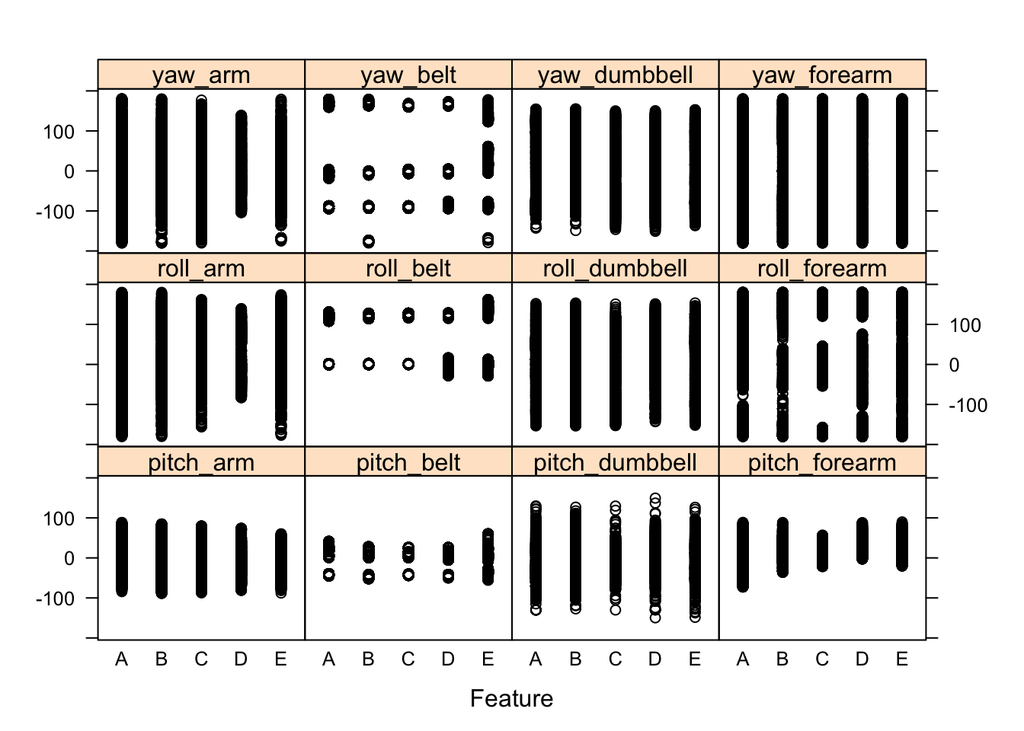

```r
transparentTheme(trans = .3)
featurePlot(x = preTrain[,c(1,2,3,14,15,16,27,28,29,40,41,42)], y = preTrain$classe,
            auto.key = list(columns = 2))
```

## Split Training Data into Training and Validation

The training set has 19,622 observations, and the testing set has 20 cases to predict. In order to find out the out of sample error of any model we are going to build, set aside 25 % of the training set into the validation set and use only 75 % to build prediction models. Here we choose to have a stratified random splitting based on the outcome variable ‘classe’.

```r
set.seed(1124)
inTrain <- createDataPartition(preTrain$classe, p = 0.75, list = FALSE)
train <- preTrain[inTrain,]
valid <- preTrain[-inTrain,]
control <- trainControl(method = "repeatedcv", number = 5, repeats = 3)
```

## Model Training and Tuning

### Random Forest

Random Forest algorithm builds an ensemble of decision trees, each of which uses a randomly sampled subset of observations and a randomly sampled subset of variables. Given a new set of observations, it averages over the predictions from all the decision trees to reach a final conclusion. According to R document, mtry is the number of variables randomly sampled as candidates at each split and ntree is the number of trees to grow. Since it’s often the case that the higher the value of ‘ntree’ the more accurate the model is, only the parameters ‘mtry’ is tuned to find out the best value for the data in this case.  
Within the training data set, we use the caret train function with random forest (‘rf’) method and choose a resampling scheme of 3 separate 5-fold cross-validations.

```r
tune <- expand.grid(.mtry=c(2,7,12))
fitRf <- train(classe ~ ., data = train, method = "rf", tuneGrid = tune,
               ntree = 10, trControl = control)
print(fitRf)
```

```
## Random Forest
##
## 14718 samples
##    52 predictor
##     5 classes: 'A', 'B', 'C', 'D', 'E'
##
## No pre-processing
## Resampling: Cross-Validated (5 fold, repeated 3 times)
## Summary of sample sizes: 11774, 11774, 11775, 11774, 11775, 11774, ...
## Resampling results across tuning parameters:
##
##   mtry  Accuracy   Kappa
##    2    0.9779409  0.9720906
##    7    0.9861396  0.9824658
##   12    0.9870452  0.9836129
##
## Accuracy was used to select the optimal model using  the largest value.
## The final value used for the model was mtry = 12.
```

With ntree set at a small number (ntree = 10), tuning mtry has found that Accuracy and Kappa are both pretty close to one for all three ‘mtry’ values.

#### Out of Sample Error

Testing our tuned Random Forest Model on the validation data set, we show the confusion Matrix below and the accuracy is 0.9881729.

```r
predictRf <- predict(fitRf, valid)
(confRf <- confusionMatrix(valid$classe, predictRf))
```

```
## Confusion Matrix and Statistics
##
##           Reference
## Prediction    A    B    C    D    E
##          A 1392    2    1    0    0
##          B   13  930    4    2    0
##          C    1    9  840    5    0
##          D    0    1    7  794    2
##          E    0    2    4    5  890
##
## Overall Statistics
##
##                Accuracy : 0.9882
##                  95% CI : (0.9847, 0.991)
##     No Information Rate : 0.2867
##     P-Value [Acc > NIR] : < 2.2e-16
##
##                   Kappa : 0.985
##  Mcnemar's Test P-Value : NA
##
## Statistics by Class:
##
##                      Class: A Class: B Class: C Class: D Class: E
## Sensitivity            0.9900   0.9852   0.9813   0.9851   0.9978
## Specificity            0.9991   0.9952   0.9963   0.9976   0.9973
## Pos Pred Value         0.9978   0.9800   0.9825   0.9876   0.9878
## Neg Pred Value         0.9960   0.9965   0.9960   0.9971   0.9995
## Prevalence             0.2867   0.1925   0.1746   0.1644   0.1819
## Detection Rate         0.2838   0.1896   0.1713   0.1619   0.1815
## Detection Prevalence   0.2845   0.1935   0.1743   0.1639   0.1837
## Balanced Accuracy      0.9946   0.9902   0.9888   0.9913   0.9975
```

```r
(accuracyRf <- confRf$overall[1])
```

```
##  Accuracy
## 0.9881729
```

The accuracy of this random forest model is 0.99 using mtry = 12 and ntree = 10.

#### Prediction on the Test Data

Use the model we tuned above on the 20 test data, we get the our first set of preditions.

```r
(predict(fitRf, preTest))
```

```
##  [1] B A B A A E D B A A B C B A E E A B B B
## Levels: A B C D E
```

### Boosting

```r
gbmGrid <- expand.grid(
                       interaction.depth = c(3,6),
                       n.trees = c(50),
                       shrinkage = c(0.1),
                       n.minobsinnode = c(10))
fitGbm <- train(classe ~ ., data = train, method="gbm",
                tuneGrid = gbmGrid, trControl = control,
                verbose = F)
print(fitGbm)
```

```
## Stochastic Gradient Boosting
##
## 14718 samples
##    52 predictor
##     5 classes: 'A', 'B', 'C', 'D', 'E'
##
## No pre-processing
## Resampling: Cross-Validated (5 fold, repeated 3 times)
## Summary of sample sizes: 11775, 11773, 11776, 11775, 11773, 11775, ...
## Resampling results across tuning parameters:
##
##   interaction.depth  Accuracy   Kappa
##   3                  0.8958178  0.8680996
##   6                  0.9503323  0.9371383
##
## Tuning parameter 'n.trees' was held constant at a value of 50
##
## Tuning parameter 'shrinkage' was held constant at a value of 0.1
##
## Tuning parameter 'n.minobsinnode' was held constant at a value of 10
## Accuracy was used to select the optimal model using  the largest value.
## The final values used for the model were n.trees = 50, interaction.depth
##  = 6, shrinkage = 0.1 and n.minobsinnode = 10.
```

This means that interaction.depth = 6 and n.trees = 50 is the best combination.

#### Out of Sample Error

To run it on the validation data set, we could find out the out of sample error rate.

```r
predictGbm <- predict(fitGbm, valid)
(confGbm <- confusionMatrix(valid$classe, predictGbm))
```

```
## Confusion Matrix and Statistics
##
##           Reference
## Prediction    A    B    C    D    E
##          A 1375   12    5    2    1
##          B   50  872   26    0    1
##          C    0   43  803    7    2
##          D    1    2   33  764    4
##          E    5   11   10   15  860
##
## Overall Statistics
##
##                Accuracy : 0.9531
##                  95% CI : (0.9468, 0.9588)
##     No Information Rate : 0.2918
##     P-Value [Acc > NIR] : < 2.2e-16
##
##                   Kappa : 0.9406
##  Mcnemar's Test P-Value : 6.187e-12
##
## Statistics by Class:
##
##                      Class: A Class: B Class: C Class: D Class: E
## Sensitivity            0.9609   0.9277   0.9156   0.9695   0.9908
## Specificity            0.9942   0.9806   0.9871   0.9903   0.9898
## Pos Pred Value         0.9857   0.9189   0.9392   0.9502   0.9545
## Neg Pred Value         0.9840   0.9828   0.9817   0.9941   0.9980
## Prevalence             0.2918   0.1917   0.1788   0.1607   0.1770
## Detection Rate         0.2804   0.1778   0.1637   0.1558   0.1754
## Detection Prevalence   0.2845   0.1935   0.1743   0.1639   0.1837
## Balanced Accuracy      0.9776   0.9541   0.9514   0.9799   0.9903
```

```r
(accuracyGbm <- confGbm$overall[1])
```

```
##  Accuracy
## 0.9530995
```

The accuracy of the boosting model is 0.95 with interaction.depth = 6 and n.trees = 50.

#### Predict on the Test Data

Using the boosting model we just tuned, we get the second set of the prediction for the 20 test cases.

```r
predict(fitGbm,preTest)
```

```
##  [1] B A B A A E D B A A B C B A E E A B B B
## Levels: A B C D E
```

### Conclusion

Using random forest and boosting algorith from the caret package and tuned the key parameters to our data, we could see that the two models could both achieve high accuracy and their predictions on the test data set we got from random forest and boosting models are the same. This demonstrated the possibility of using wearable devices data to tell if a movement is performed in the correct way or not which could have important applications in developing smart devices in the real world.